# Análisis de redes génicas asociadas al fenotipo HP:0002344

Progressive neurologic deterioration

Patricia Rodríguez Lidueña, Achraf Ousti El Moussati, Aissa Omar El Hammouti Chachoui, Hugo Salas Calderón

2025-11-14

# 1 Introducción

# 2 Flujo de Trabajo

## 2.1 Obtención de Genes desde HPO

### 2.1.1 Descripción del fenotipo

El término HPO:0002344 – Progressive neurologic deterioration describe el deterioro neurológico progresivo característico de múltiples enfermedades neurodegenerativas raras. Este fenotipo agrupa patologías con heterogeneidad genética pero con mecanismos de neurodegeneración potencialmente convergentes.

### 2.1.2 Acceso mediante API de HPO

Utilizamos la API de la Human Phenotype Ontology para obtener programáticamente la lista de genes asociados al fenotipo HP:0002344.

```r
# ID del fenotipo HP:0002344
hpo_id <- "HP:0002344"

# Construcción de la URL de la API
url <- paste0("https://ontology.jax.org/api/network/annotation/", hpo_id)

# Realizar petición a la API
response <- GET(url)

# Parsear respuesta JSON
data <- httr::content(response, "text")
Encoding(data) <- "UTF-8"
genes_hpo <- fromJSON(data)$genes
```

**✓ Total de genes obtenidos:** 73 genes asociados a HP:0002344

```r
# Mostrar tabla con los primeros 10 genes
head(genes_hpo, 10) %>%
  kbl(caption = "Primeros 10 genes asociados al fenotipo HP:0002344") %>%
  kable_styling(bootstrap_options = c("striped", "hover", "condensed", "responsive"),
                full_width = FALSE,
                position = "center") %>%
  row_spec(0, bold = TRUE, color = "white", background = "#3498db")
```

Primeros 10 genes asociados al fenotipo HP:0002344

| id | name |
| --- | --- |
| NCBIGene:6513 | SLC2A1 |
| NCBIGene:478 | ATP1A3 |
| NCBIGene:23221 | RHOBTB2 |
| NCBIGene:477 | ATP1A2 |
| NCBIGene:6507 | SLC1A3 |
| NCBIGene:4568 | MT-TL2 |
| NCBIGene:6326 | SCN2A |
| NCBIGene:773 | CACNA1A |
| NCBIGene:8893 | EIF2B5 |
| NCBIGene:1497 | CTNS |

### 2.1.3 Filtrado y validación de genes

Se realiza un filtrado inicial para eliminar duplicados y se seleccionan los genes con mayor evidencia de asociación al fenotipo.

```r
# Eliminar duplicados y valores NA
genes_clean <- genes_hpo[!duplicated(genes_hpo$name) & !is.na(genes_hpo$name), ]

# Crear lista de genes para análisis posterior
gene_list <- genes_clean$name
```

**Genes únicos tras filtrado:** 73 genes

```r
# Mostrar primeros 20 genes
data.frame(
  Index = 1:min(20, length(gene_list)),
  Gene = gene_list[1:min(20, length(gene_list))]
) %>%
  kbl(caption = "Primeros 20 genes filtrados") %>%
  kable_styling(bootstrap_options = c("striped", "hover", "condensed"),
                full_width = FALSE) %>%
  row_spec(0, bold = TRUE, color = "white", background = "#2ecc71")
```

Primeros 20 genes filtrados

| Index | Gene |
| --- | --- |
| 1 | SLC2A1 |
| 2 | ATP1A3 |
| 3 | RHOBTB2 |
| 4 | ATP1A2 |
| 5 | SLC1A3 |
| 6 | MT-TL2 |
| 7 | SCN2A |
| 8 | CACNA1A |
| 9 | EIF2B5 |
| 10 | CTNS |
| 11 | LMNB1 |
| 12 | CERS1 |
| 13 | ERCC6 |
| 14 | GCH1 |
| 15 | HNF4A |
| 16 | GBA1 |
| 17 | HSD17B10 |
| 18 | HEPACAM |
| 19 | SYNJ1 |
| 20 | TREX1 |

### 2.1.4 Genes de interés específicos

Para nuestro análisis nos centraremos en los genes MECP2, IARS2 y GRN, previamente identificados en la literatura como causales de enfermedades representativas del fenotipo HP:0002344.

```r
# Genes de interés principal
focus_genes <- c("MECP2", "IARS2", "GRN")

# Verificar presencia en la lista
genes_present <- focus_genes %in% gene_list

# Crear dataframe para mostrar
verification_df <- data.frame(
  Gen = focus_genes,
  Estado = ifelse(genes_present, "✓ PRESENTE", "✗ AUSENTE"),
  stringsAsFactors = FALSE
)

verification_df %>%
  kbl(caption = "Verificación de genes de interés") %>%
  kable_styling(bootstrap_options = c("striped", "hover"),
                full_width = FALSE) %>%
  row_spec(0, bold = TRUE, color = "white", background = "#9b59b6") %>%
  column_spec(2, bold = TRUE,
              color = ifelse(genes_present, "#27ae60", "#e74c3c"))
```

Verificación de genes de interés

| Gen | Estado |
| --- | --- |
| MECP2 | ✓ PRESENTE |
| IARS2 | ✓ PRESENTE |
| GRN | ✓ PRESENTE |

## 2.2 Construcción de Red PPI con STRINGdb

### 2.2.1 Inicialización de STRINGdb

Se inicializa la conexión con la base de datos STRING versión 12.0, estableciendo un umbral de confianza alto (≥0.7) para garantizar interacciones de alta calidad.

```r
# Inicializar STRINGdb
# species = 9606 (Homo sapiens)
# score_threshold = 700 (alta confianza, ≥0.7)
string_db <- STRINGdb$new(species = 9606,
                          score_threshold = 700,
                          input_directory = "",
                          version = "12.0")
```

**✓ STRINGdb inicializado correctamente**  
**Especie:** Homo sapiens (NCBI tax ID: 9606)  
**Umbral de confianza:** 0.70

### 2.2.2 Mapeo de genes a identificadores STRING

```r
# Crear dataframe con nombres de genes
genes_df <- data.frame(name = gene_list, stringsAsFactors = FALSE)

# Mapear genes a identificadores STRING
string_ids <- string_db$map(genes_df, "name", removeUnmappedRows = TRUE)
# Crear resumen de mapeo
mapping_summary <- data.frame(
  Concepto = c("Genes mapeados exitosamente", "Genes no mapeados"),
  Cantidad = c(nrow(string_ids), nrow(genes_df) - nrow(string_ids)),
  Porcentaje = c(
    paste0(round(100 * nrow(string_ids) / nrow(genes_df), 1), "%"),
    paste0(round(100 * (nrow(genes_df) - nrow(string_ids)) / nrow(genes_df), 1), "%")
  )
)

mapping_summary %>%
  kbl(caption = "Resumen del mapeo de genes a STRING") %>%
  kable_styling(bootstrap_options = c("striped", "hover"),
                full_width = FALSE) %>%
  row_spec(0, bold = TRUE, color = "white", background = "#e67e22") %>%
  row_spec(1, background = "#d5f4e6")
```

Resumen del mapeo de genes a STRING

| Concepto | Cantidad | Porcentaje |
| --- | --- | --- |
| Genes mapeados exitosamente | 71 | 97.3% |
| Genes no mapeados | 2 | 2.7% |

```r
# Mostrar ejemplos de mapeo
head(string_ids[, c("name", "STRING_id")], 10) %>%
  kbl(caption = "Ejemplos de genes mapeados") %>%
  kable_styling(bootstrap_options = c("striped", "hover", "condensed"),
                full_width = FALSE) %>%
  row_spec(0, bold = TRUE, color = "white", background = "#34495e")
```

Ejemplos de genes mapeados

| name | STRING_id |
| --- | --- |
| SLC2A1 | 9606.ENSP00000416293 |
| ATP1A3 | 9606.ENSP00000444688 |
| RHOBTB2 | 9606.ENSP00000427926 |
| ATP1A2 | 9606.ENSP00000354490 |
| SLC1A3 | 9606.ENSP00000265113 |
| SCN2A | 9606.ENSP00000490107 |
| CACNA1A | 9606.ENSP00000489829 |
| EIF2B5 | 9606.ENSP00000497160 |
| CTNS | 9606.ENSP00000371294 |
| LMNB1 | 9606.ENSP00000261366 |

### 2.2.3 Obtención de interacciones proteína-proteína

```r
# Obtener interacciones PPI desde STRING
interaction_network <- string_db$get_interactions(string_ids$STRING_id)

# Eliminar duplicados
interaction_network <- unique(interaction_network[, 1:2])

# Convertir IDs STRING a nombres de genes
interaction_network$from <- string_ids$name[match(interaction_network$from,
                                                   string_ids$STRING_id)]
interaction_network$to <- string_ids$name[match(interaction_network$to,
                                                 string_ids$STRING_id)]

# Eliminar interacciones con NAs
interaction_network <- interaction_network[complete.cases(interaction_network), ]
```

**✓ Interacciones obtenidas:** 43 interacciones PPI

```r
head(interaction_network, 10) %>%
  kbl(caption = "Primeras 10 interacciones proteína-proteína") %>%
  kable_styling(bootstrap_options = c("striped", "hover", "condensed"),
                full_width = FALSE) %>%
  row_spec(0, bold = TRUE, color = "white", background = "#16a085")
```

Primeras 10 interacciones proteína-proteína

|  | from | to |
| --- | --- | --- |
| 1 | ARSA | IDUA |
| 3 | NAGLU | IDUA |
| 5 | RRM2B | CMPK2 |
| 7 | ARSA | GALC |
| 9 | ARSA | SUMF1 |
| 11 | PTS | QDPR |
| 13 | ARSA | GLB1 |
| 15 | GALC | GLB1 |
| 17 | HEXB | GLB1 |
| 19 | GALC | GBA1 |

### 2.2.4 Estadísticas básicas de la red

```r
# Crear lista de genes únicos en la red
genes_in_network <- unique(c(interaction_network$from, interaction_network$to))

# Calcular densidad
network_density <- round(nrow(interaction_network) / (length(genes_in_network) *
                                   (length(genes_in_network) - 1) / 2), 4)

# Crear dataframe de estadísticas
network_stats <- data.frame(
  Métrica = c("Número de nodos (genes)", "Número de aristas (interacciones)", "Densidad de red"),
  Valor = c(length(genes_in_network), nrow(interaction_network), network_density)
)

network_stats %>%
  kbl(caption = "Estadísticas básicas de la red PPI") %>%
  kable_styling(bootstrap_options = c("striped", "hover"),
                full_width = FALSE) %>%
  row_spec(0, bold = TRUE, color = "white", background = "#2c3e50") %>%
  column_spec(1, bold = TRUE, width = "15em") %>%
  column_spec(2, width = "10em")
```

Estadísticas básicas de la red PPI

| Métrica | Valor |
| --- | --- |
| Número de nodos (genes) | 39.000 |
| Número de aristas (interacciones) | 43.000 |
| Densidad de red | 0.058 |

## 2.3 Análisis Estructural con igraph

### 2.3.1 Conversión a objeto igraph

```r
# Crear objeto igraph a partir de la red de interacciones
g <- graph_from_data_frame(interaction_network, directed = FALSE)

# Simplificar grafo (eliminar loops y aristas múltiples)
g <- simplify(g, remove.multiple = TRUE, remove.loops = TRUE)

# Crear dataframe informativo
graph_info <- data.frame(
  Propiedad = c("Tipo de grafo", "Número de vértices", "Número de aristas"),
  Valor = c(
    ifelse(is_directed(g), "Dirigido", "No dirigido"),
    vcount(g),
    ecount(g)
  )
)

graph_info %>%
  kbl(caption = "Propiedades del grafo creado") %>%
  kable_styling(bootstrap_options = c("striped", "hover"),
                full_width = FALSE) %>%
  row_spec(0, bold = TRUE, color = "white", background = "#27ae60")
```

Propiedades del grafo creado

| Propiedad | Valor |
| --- | --- |
| Tipo de grafo | No dirigido |
| Número de vértices | 39 |
| Número de aristas | 43 |

### 2.3.2 Cálculo de métricas topológicas

```r
# Grado de nodos
degree_vals <- degree(g)

# Centralidad de intermediación (betweenness)
betweenness_vals <- betweenness(g, normalized = TRUE)

# Centralidad de cercanía (closeness)
closeness_vals <- closeness(g, normalized = TRUE)

# Coeficiente de agrupamiento (clustering coefficient)
clustering_vals <- transitivity(g, type = "local")
clustering_vals[is.na(clustering_vals)] <- 0

# Crear dataframe con métricas
node_metrics <- data.frame(
  gene = V(g)$name,
  degree = degree_vals,
  betweenness = round(betweenness_vals, 4),
  closeness = round(closeness_vals, 4),
  clustering = round(clustering_vals, 4)
)

# Ordenar por grado (de mayor a menor)
node_metrics <- node_metrics[order(-node_metrics$degree), ]
```

```r
head(node_metrics, 10) %>%
  kbl(caption = "Top 10 genes por grado (Hubs de la red)",
      col.names = c("Gen", "Grado", "Betweenness", "Closeness", "Clustering")) %>%
  kable_styling(bootstrap_options = c("striped", "hover", "condensed"),
                full_width = FALSE) %>%
  row_spec(0, bold = TRUE, color = "white", background = "#c0392b") %>%
  column_spec(1, bold = TRUE) %>%
  column_spec(2, color = "white", background = "#e74c3c", bold = TRUE)
```

Top 10 genes por grado (Hubs de la red)

|  | Gen | Grado | Betweenness | Closeness | Clustering |
| --- | --- | --- | --- | --- | --- |
| ARSA | ARSA | 5 | 0.0356 | 0.6250 | 0.2000 |
| SDHA | SDHA | 5 | 0.0014 | 0.8571 | 0.8000 |
| CYC1 | CYC1 | 5 | 0.0028 | 0.8571 | 0.7000 |
| SDHB | SDHB | 5 | 0.0014 | 0.8571 | 0.8000 |
| SDHD | SDHD | 5 | 0.0014 | 0.8571 | 0.8000 |
| NDUFA6 | NDUFA6 | 5 | 0.0028 | 0.8571 | 0.7000 |
| GALC | GALC | 4 | 0.0047 | 0.5556 | 0.6667 |
| GLB1 | GLB1 | 4 | 0.0147 | 0.5000 | 0.3333 |
| PSAP | PSAP | 4 | 0.0247 | 0.5556 | 0.3333 |
| GBA1 | GBA1 | 3 | 0.0028 | 0.4545 | 0.6667 |

### 2.3.3 Métricas globales de la red

```r
# Diámetro de la red
diameter_val <- diameter(g, directed = FALSE)

# Camino medio más corto
avg_path_length <- mean_distance(g, directed = FALSE)

# Coeficiente de agrupamiento global
global_clustering <- transitivity(g, type = "global")

# Modularidad (usando algoritmo Louvain)
louvain_clusters <- cluster_louvain(g)
modularity_val <- modularity(louvain_clusters)

# Densidad de la red
density_val <- edge_density(g)

# Número de componentes
n_components <- components(g)$no

# Crear dataframe de métricas globales
global_metrics_df <- data.frame(
  Métrica = c(
    "Diámetro de la red",
    "Longitud promedio de camino más corto",
    "Coeficiente de agrupamiento global",
    "Modularidad (Louvain)",
    "Densidad de la red",
    "Número de componentes conectados"
  ),
  Valor = c(
    diameter_val,
    round(avg_path_length, 3),
    round(global_clustering, 3),
    round(modularity_val, 3),
    round(density_val, 4),
    n_components
  )
)

global_metrics_df %>%
  kbl(caption = "Métricas globales de la red") %>%
  kable_styling(bootstrap_options = c("striped", "hover"),
                full_width = FALSE) %>%
  row_spec(0, bold = TRUE, color = "white", background = "#8e44ad") %>%
  column_spec(1, bold = TRUE, width = "20em") %>%
  column_spec(2, width = "8em", color = "white", background = "#9b59b6")
```

Métricas globales de la red

| Métrica | Valor |
| --- | --- |
| Diámetro de la red | 5.000 |
| Longitud promedio de camino más corto | 1.926 |
| Coeficiente de agrupamiento global | 0.606 |
| Modularidad (Louvain) | 0.757 |
| Densidad de la red | 0.058 |
| Número de componentes conectados | 10.000 |

### 2.3.4 Distribución de grado

Estadísticas de distribución de grado

| Estadística | Valor |
| --- | --- |
| Grado mínimo | 1.00 |
| Grado máximo | 5.00 |
| Grado medio | 2.21 |
| Grado mediano | 2.00 |

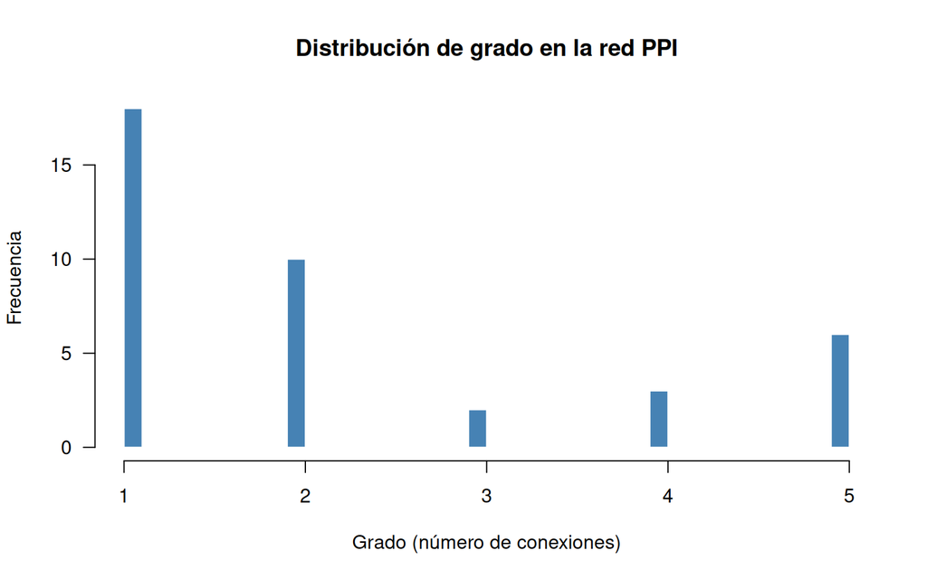

```r
# Histograma de distribución de grado
hist(degree_vals,
     breaks = 30,
     col = "steelblue",
     border = "white",
     main = "Distribución de grado en la red PPI",
     xlab = "Grado (número de conexiones)",
     ylab = "Frecuencia",
     las = 1)

# Estadísticas descriptivas del grado
degree_stats <- data.frame(
  Estadística = c("Grado mínimo", "Grado máximo", "Grado medio", "Grado mediano"),
  Valor = c(
    min(degree_vals),
    max(degree_vals),
    round(mean(degree_vals), 2),
    median(degree_vals)
  )
)

degree_stats %>%
  kbl(caption = "Estadísticas de distribución de grado") %>%
  kable_styling(bootstrap_options = c("striped", "hover"),
                full_width = FALSE) %>%
  row_spec(0, bold = TRUE, color = "white", background = "#3498db")
```

## 2.4 Visualización de la Red

### 2.4.1 Visualización básica (layout Fruchterman-Reingold)

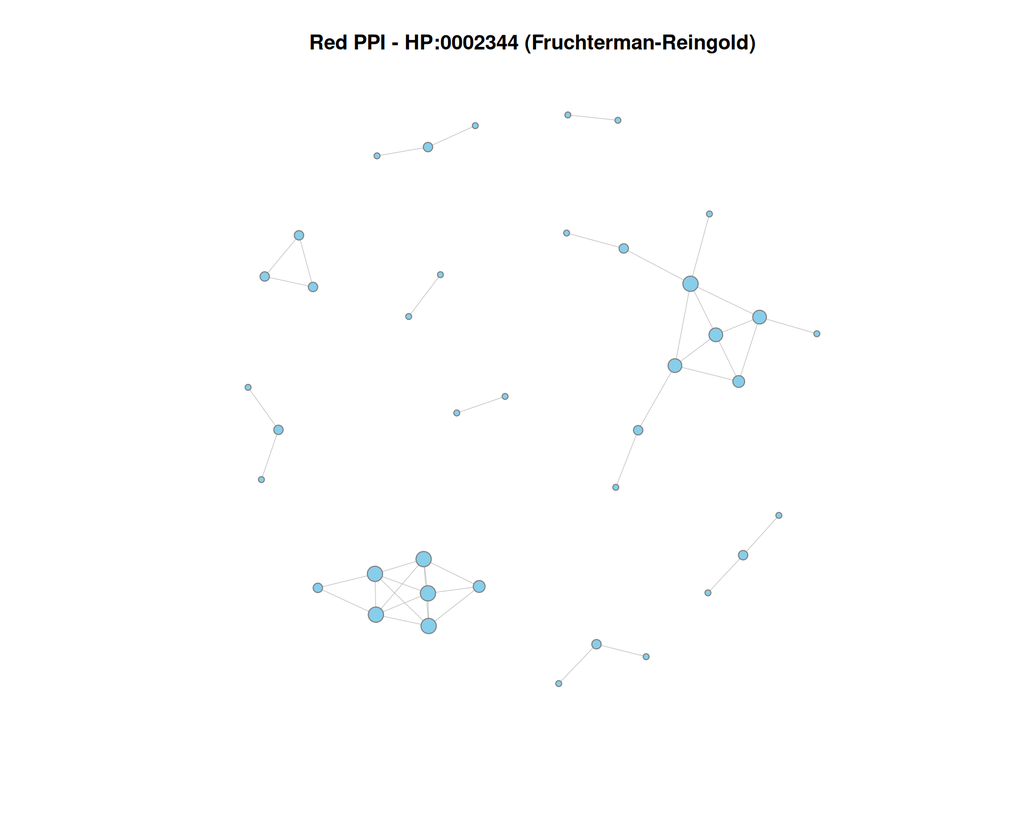

```r
set.seed(123)

# Layout Fruchterman-Reingold
layout_fr <- layout_with_fr(g)

# Asignar tamaño de nodos según grado
vertex_size <- log(degree_vals + 1) * 3

# Plot
plot(g,
     layout = layout_fr,
     vertex.size = vertex_size,
     vertex.color = "skyblue",
     vertex.frame.color = "gray50",
     vertex.label = NA,
     edge.width = 0.5,
     edge.color = "gray70",
     main = "Red PPI - HP:0002344 (Fruchterman-Reingold)")
```

### 2.4.2 Visualización destacando genes de interés

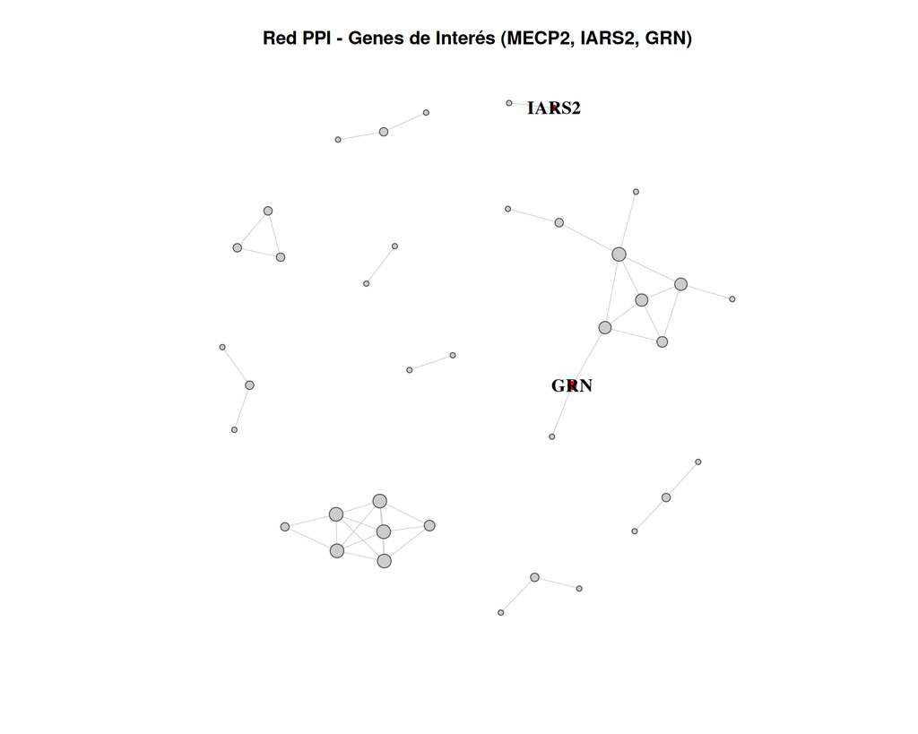

```r
set.seed(123)

# Identificar genes de interés en la red
focus_in_network <- focus_genes[focus_genes %in% V(g)$name]

# Crear vector de colores
vertex_colors <- rep("gray80", vcount(g))
vertex_colors[V(g)$name %in% focus_in_network] <- "red"

# Crear vector de etiquetas (solo para genes de interés)
vertex_labels <- rep(NA, vcount(g))
vertex_labels[V(g)$name %in% focus_in_network] <- V(g)$name[V(g)$name %in% focus_in_network]

# Plot
plot(g,
     layout = layout_fr,
     vertex.size = vertex_size,
     vertex.color = vertex_colors,
     vertex.frame.color = "gray30",
     vertex.label = vertex_labels,
     vertex.label.cex = 1.2,
     vertex.label.color = "black",
     vertex.label.font = 2,
     edge.width = 0.5,
     edge.color = "gray70",
     main = "Red PPI - Genes de Interés (MECP2, IARS2, GRN)")
```

### 2.4.3 Visualización con ggraph

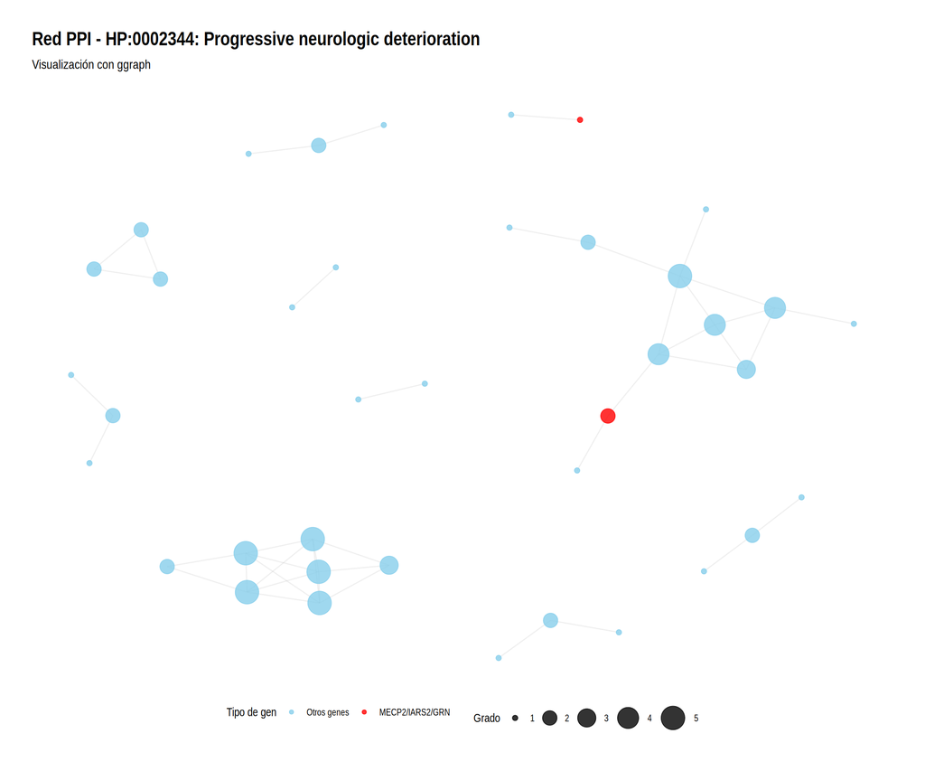

```r
# Convertir a tidygraph
g_tidy <- as_tbl_graph(g) %>%
  activate(nodes) %>%
  mutate(
    degree = degree_vals,
    focus = name %in% focus_in_network
  )

# Plot con ggraph
ggraph(g_tidy, layout = 'fr') +
  geom_edge_link(alpha = 0.2, color = "gray70") +
  geom_node_point(aes(size = degree, color = focus), alpha = 0.8) +
  scale_color_manual(values = c("FALSE" = "skyblue", "TRUE" = "red"),
                     labels = c("Otros genes", "MECP2/IARS2/GRN")) +
  scale_size_continuous(range = c(2, 10)) +
  labs(title = "Red PPI - HP:0002344: Progressive neurologic deterioration",
       subtitle = "Visualización con ggraph",
       color = "Tipo de gen",
       size = "Grado") +
  theme_graph() +
  theme(legend.position = "bottom")
```

## 2.5 Detección de Comunidades

### 2.5.1 Algoritmo de Louvain

```r
set.seed(123)

# Clustering con Louvain
louvain_communities <- cluster_louvain(g)

# Número de comunidades
n_communities_louvain <- length(unique(membership(louvain_communities)))

# Crear resumen
louvain_summary <- data.frame(
  Métrica = c("Número de comunidades detectadas", "Modularidad"),
  Valor = c(n_communities_louvain, round(modularity(louvain_communities), 3))
)

louvain_summary %>%
  kbl(caption = "Clustering Louvain - Resumen") %>%
  kable_styling(bootstrap_options = c("striped", "hover"),
                full_width = FALSE) %>%
  row_spec(0, bold = TRUE, color = "white", background = "#e74c3c")
```

Clustering Louvain - Resumen

| Métrica | Valor |
| --- | --- |
| Número de comunidades detectadas | 10.000 |
| Modularidad | 0.757 |

```r
# Tabla de tamaños de comunidades
community_sizes_table <- as.data.frame(table(membership(louvain_communities)))
colnames(community_sizes_table) <- c("Comunidad", "Número de genes")

community_sizes_table %>%
  kbl(caption = "Tamaños de las comunidades (Louvain)") %>%
  kable_styling(bootstrap_options = c("striped", "hover", "condensed"),
                full_width = FALSE) %>%
  row_spec(0, bold = TRUE, color = "white", background = "#34495e")
```

Tamaños de las comunidades (Louvain)

| Comunidad | Número de genes |
| --- | --- |
| 1 | 11 |
| 2 | 3 |
| 3 | 3 |
| 4 | 7 |
| 5 | 2 |
| 6 | 2 |
| 7 | 2 |
| 8 | 3 |
| 9 | 3 |
| 10 | 3 |

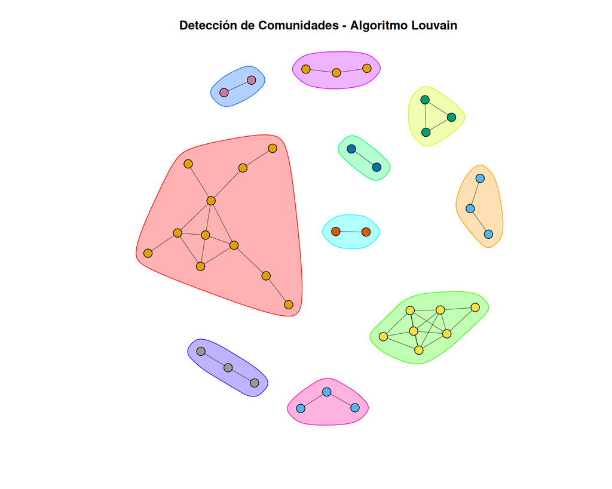

```r
set.seed(123)

# Visualización de comunidades Louvain
plot(louvain_communities, g,
     vertex.size = 5,
     vertex.label = NA,
     edge.width = 0.5,
     main = "Detección de Comunidades - Algoritmo Louvain")
```

### 2.5.2 Algoritmo Walktrap

```r
set.seed(123)

# Clustering con Walktrap
walktrap_communities <- cluster_walktrap(g, steps = 4)

# Número de comunidades
n_communities_walktrap <- length(unique(membership(walktrap_communities)))

# Crear resumen
walktrap_summary <- data.frame(
  Métrica = c("Número de comunidades detectadas", "Modularidad"),
  Valor = c(n_communities_walktrap, round(modularity(walktrap_communities), 3))
)

walktrap_summary %>%
  kbl(caption = "Clustering Walktrap - Resumen") %>%
  kable_styling(bootstrap_options = c("striped", "hover"),
                full_width = FALSE) %>%
  row_spec(0, bold = TRUE, color = "white", background = "#16a085")
```

Clustering Walktrap - Resumen

| Métrica | Valor |
| --- | --- |
| Número de comunidades detectadas | 10.000 |
| Modularidad | 0.757 |

```r
# Tabla de tamaños de comunidades
walktrap_sizes_table <- as.data.frame(table(membership(walktrap_communities)))
colnames(walktrap_sizes_table) <- c("Comunidad", "Número de genes")

walktrap_sizes_table %>%
  kbl(caption = "Tamaños de las comunidades (Walktrap)") %>%
  kable_styling(bootstrap_options = c("striped", "hover", "condensed"),
                full_width = FALSE) %>%
  row_spec(0, bold = TRUE, color = "white", background = "#1abc9c")
```

Tamaños de las comunidades (Walktrap)

[output not shown]

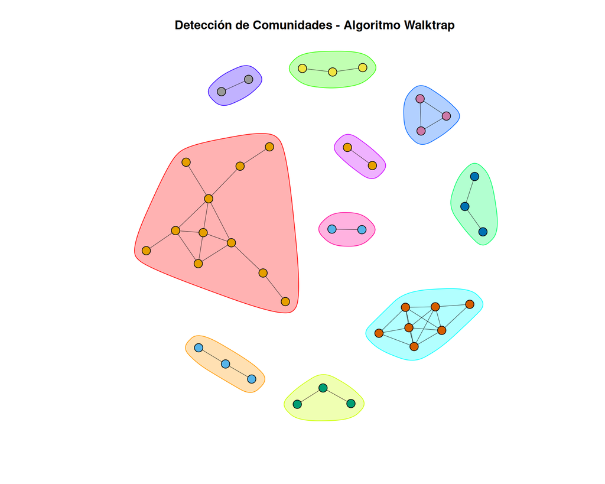

```r
set.seed(123)

# Visualización de comunidades Walktrap
plot(walktrap_communities, g,
     vertex.size = 5,
     vertex.label = NA,
     edge.width = 0.5,
     main = "Detección de Comunidades - Algoritmo Walktrap")
```

### 2.5.3 Comunidades solapadas con K-clique

```r
set.seed(123)

# Detección de comunidades solapadas usando k-clique percolation (k=3)
cliques_list <- cliques(g, min = 3)

# Crear resumen
kclique_summary <- data.frame(
  Métrica = c("Número de cliques (k>=3)", "Número de nodos", "Número de aristas"),
  Valor = c(length(cliques_list), vcount(g), ecount(g))
)

kclique_summary %>%
  kbl(caption = "Comunidades solapadas (K-clique percolation) - Resumen") %>%
  kable_styling(bootstrap_options = c("striped", "hover"),
                full_width = FALSE) %>%
  row_spec(0, bold = TRUE, color = "white", background = "#f39c12")
```

Comunidades solapadas (K-clique percolation) - Resumen

| Métrica | Valor |
| --- | --- |
| Número de cliques (k>=3) | 26 |
| Número de nodos | 39 |
| Número de aristas | 43 |

```r
# Identificar nodos que pertenecen a múltiples cliques (solapamiento)
node_clique_membership <- sapply(V(g)$name, function(node) {
  sum(sapply(cliques_list, function(clique) node %in% names(clique)))
})

# Top 10 nodos con mayor solapamiento
top_overlap <- head(sort(node_clique_membership, decreasing = TRUE), 10)
overlap_df <- data.frame(
  Gen = names(top_overlap),
  `Número de cliques` = as.numeric(top_overlap)
)

overlap_df %>%
  kbl(caption = "Top 10 nodos con mayor solapamiento entre cliques") %>%
  kable_styling(bootstrap_options = c("striped", "hover", "condensed"),
                full_width = FALSE) %>%
  row_spec(0, bold = TRUE, color = "white", background = "#e67e22") %>%
  column_spec(1, bold = TRUE)
```

Top 10 nodos con mayor solapamiento entre cliques

| Gen | Número.de.cliques |
| --- | --- |
| SDHA | 14 |
| SDHB | 14 |
| SDHD | 14 |
| CYC1 | 12 |
| NDUFA6 | 12 |
| GALC | 4 |
| SDHAF1 | 4 |
| ARSA | 2 |
| GLB1 | 2 |
| GBA1 | 2 |

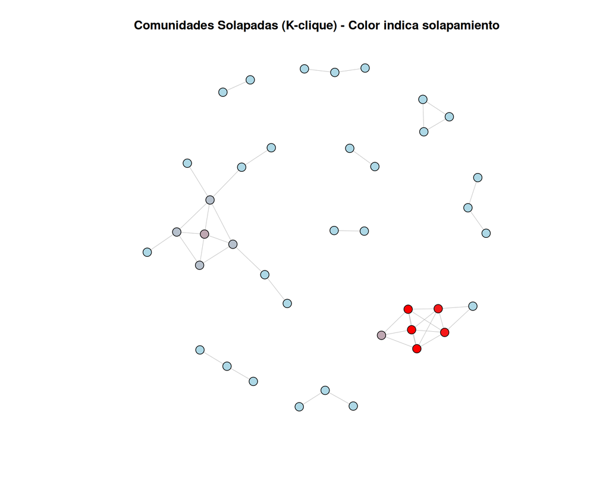

```r
# Visualización: resaltar nodos con mayor solapamiento
vertex_colors <- colorRampPalette(c("lightblue", "red"))(10)
overlap_quantiles <- cut(node_clique_membership, breaks = 10, labels = FALSE)
overlap_quantiles[is.na(overlap_quantiles)] <- 1

plot(g,
     vertex.size = 5,
     vertex.color = vertex_colors[overlap_quantiles],
     vertex.label = NA,
     edge.width = 0.5,
     main = "Comunidades Solapadas (K-clique) - Color indica solapamiento")
```

### 2.5.4 Análisis de genes por comunidad (Louvain)

```r
# Asignar comunidades a genes
community_membership <- membership(louvain_communities)

# Separar genes por comunidad
genes_by_community <- split(V(g)$name, community_membership)

# Ordenar comunidades por tamaño
community_sizes <- sapply(genes_by_community, length)
top_communities <- order(-community_sizes)[1:min(3, length(community_sizes))]
```

**ℹ Análisis de genes por comunidad**  
Se muestran las 3 comunidades más grandes detectadas por el algoritmo de Louvain

```r
for(i in top_communities){
  cat(paste0("\n#### Comunidad ", i, " (", length(genes_by_community[[i]]), " genes)\n\n"))

  # Mostrar genes en formato de tabla
  genes_df <- data.frame(
    Index = 1:length(genes_by_community[[i]]),
    Gen = genes_by_community[[i]]
  )

  print(
    genes_df %>%
      kbl() %>%
      kable_styling(bootstrap_options = c("striped", "hover", "condensed"),
                    full_width = FALSE) %>%
      row_spec(0, bold = TRUE, color = "white", background = "#95a5a6")
  )
  cat("\n\n")
}
```

[output not shown]

[output cut: 70 more lines]

[output not shown]

## 2.6 Análisis de Genes de Interés

### 2.6.1 Subred de MECP2

```r
if("MECP2" %in% V(g)$name){
  # Obtener vecinos de MECP2
  mecp2_neighbors <- neighbors(g, "MECP2")

  # Crear subgrafo
  mecp2_subgraph <- induced_subgraph(g, c("MECP2", names(mecp2_neighbors)))

  # Crear resumen
  mecp2_summary <- data.frame(
    Métrica = c("Nodos en subred", "Aristas en subred"),
    Valor = c(vcount(mecp2_subgraph), ecount(mecp2_subgraph))
  )

  mecp2_summary %>%
    kbl(caption = "Subred MECP2 - Resumen") %>%
    kable_styling(bootstrap_options = c("striped", "hover"),
                  full_width = FALSE) %>%
    row_spec(0, bold = TRUE, color = "white", background = "#3498db")

  # Mostrar genes vecinos
  neighbors_df <- data.frame(
    Index = 1:length(names(mecp2_neighbors)),
    Gen_vecino = names(mecp2_neighbors)
  )

  neighbors_df %>%
    kbl(caption = "Genes vecinos de MECP2") %>%
    kable_styling(bootstrap_options = c("striped", "hover", "condensed"),
                  full_width = FALSE) %>%
    row_spec(0, bold = TRUE, color = "white", background = "#2980b9")

  # Visualización
  set.seed(123)
  plot(mecp2_subgraph,
       vertex.size = 10,
       vertex.color = ifelse(V(mecp2_subgraph)$name == "MECP2", "red", "lightblue"),
       vertex.label.cex = 0.8,
       vertex.label.color = "black",
       edge.width = 2,
       edge.color = "gray50",
       main = "Subred de MECP2 y sus interacciones directas")
} else {
  cat('<div class="alert alert-warning">\n')
  cat('<strong>⚠ MECP2 no encontrado en la red.</strong>\n')
  cat('</div>\n')
}
```

```
## <div class="alert alert-warning">
## <strong>⚠ MECP2 no encontrado en la red.</strong>
## </div>
```

### 2.6.2 Subred de IARS2

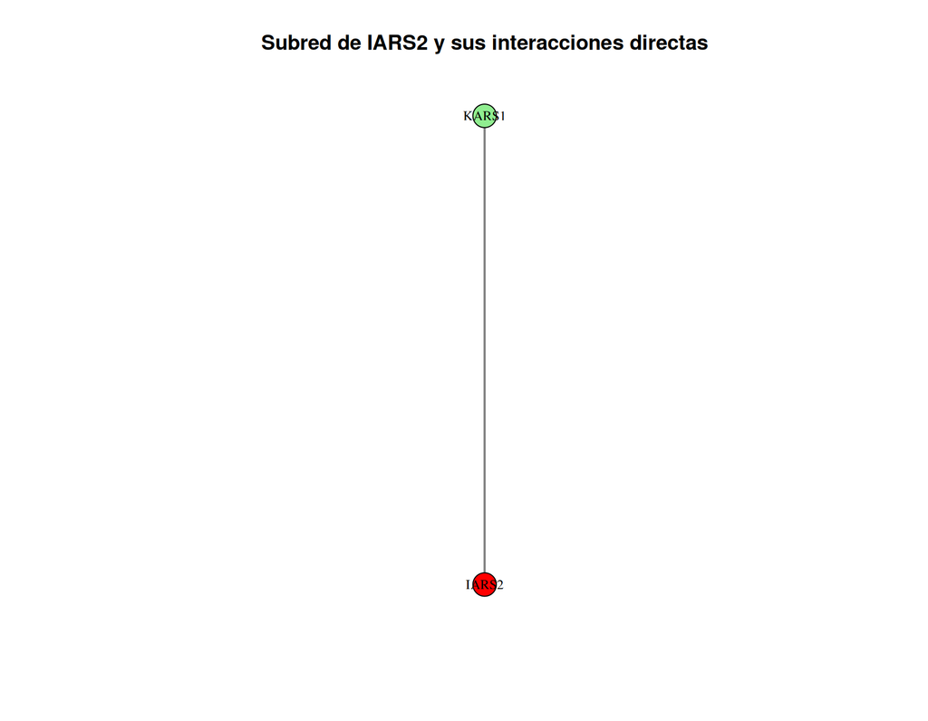

```r
if("IARS2" %in% V(g)$name){
  # Obtener vecinos de IARS2
  iars2_neighbors <- neighbors(g, "IARS2")

  # Crear subgrafo
  iars2_subgraph <- induced_subgraph(g, c("IARS2", names(iars2_neighbors)))

  # Crear resumen
  iars2_summary <- data.frame(
    Métrica = c("Nodos en subred", "Aristas en subred"),
    Valor = c(vcount(iars2_subgraph), ecount(iars2_subgraph))
  )

  iars2_summary %>%
    kbl(caption = "Subred IARS2 - Resumen") %>%
    kable_styling(bootstrap_options = c("striped", "hover"),
                  full_width = FALSE) %>%
    row_spec(0, bold = TRUE, color = "white", background = "#2ecc71")

  # Mostrar genes vecinos
  neighbors_df <- data.frame(
    Index = 1:length(names(iars2_neighbors)),
    Gen_vecino = names(iars2_neighbors)
  )

  neighbors_df %>%
    kbl(caption = "Genes vecinos de IARS2") %>%
    kable_styling(bootstrap_options = c("striped", "hover", "condensed"),
                  full_width = FALSE) %>%
    row_spec(0, bold = TRUE, color = "white", background = "#27ae60")

  # Visualización
  set.seed(123)
  plot(iars2_subgraph,
       vertex.size = 10,
       vertex.color = ifelse(V(iars2_subgraph)$name == "IARS2", "red", "lightgreen"),
       vertex.label.cex = 0.8,
       vertex.label.color = "black",
       edge.width = 2,
       edge.color = "gray50",
       main = "Subred de IARS2 y sus interacciones directas")
} else {
  cat('<div class="alert alert-warning">\n')
  cat('<strong>⚠ IARS2 no encontrado en la red.</strong>\n')
  cat('</div>\n')
}
```

### 2.6.3 Subred de GRN

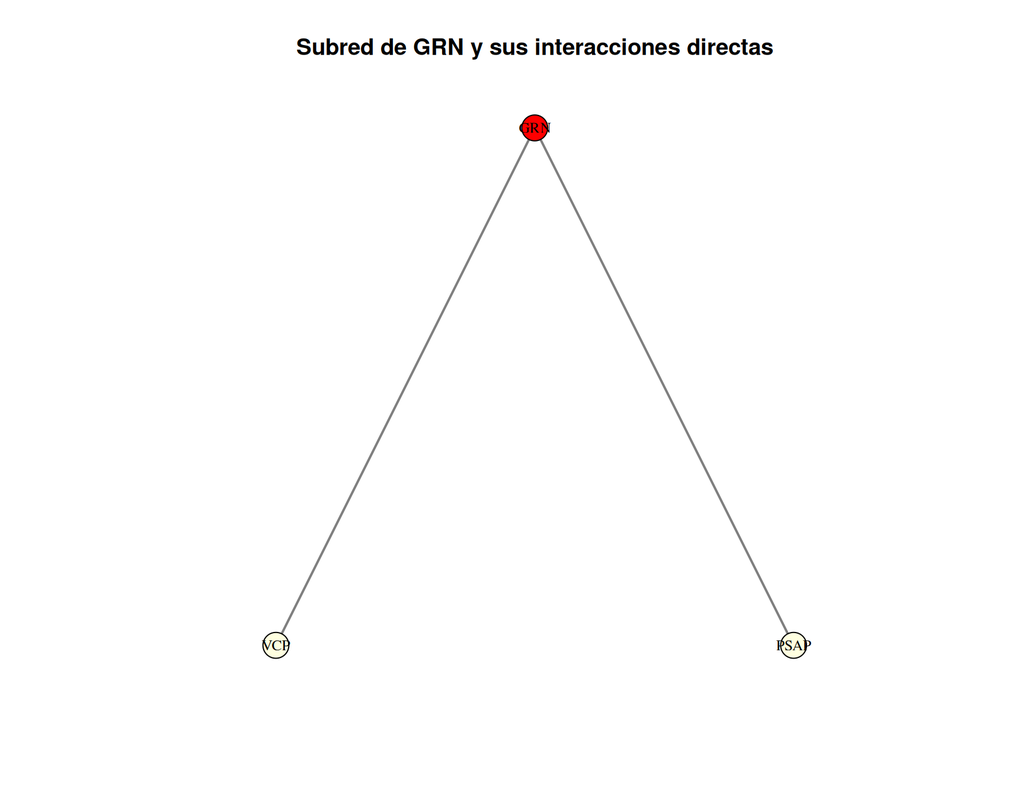

```r
if("GRN" %in% V(g)$name){
  # Obtener vecinos de GRN
  grn_neighbors <- neighbors(g, "GRN")

  # Crear subgrafo
  grn_subgraph <- induced_subgraph(g, c("GRN", names(grn_neighbors)))

  # Crear resumen
  grn_summary <- data.frame(
    Métrica = c("Nodos en subred", "Aristas en subred"),
    Valor = c(vcount(grn_subgraph), ecount(grn_subgraph))
  )

  grn_summary %>%
    kbl(caption = "Subred GRN - Resumen") %>%
    kable_styling(bootstrap_options = c("striped", "hover"),
                  full_width = FALSE) %>%
    row_spec(0, bold = TRUE, color = "white", background = "#f39c12")

  # Mostrar genes vecinos
  neighbors_df <- data.frame(
    Index = 1:length(names(grn_neighbors)),
    Gen_vecino = names(grn_neighbors)
  )

  neighbors_df %>%
    kbl(caption = "Genes vecinos de GRN") %>%
    kable_styling(bootstrap_options = c("striped", "hover", "condensed"),
                  full_width = FALSE) %>%
    row_spec(0, bold = TRUE, color = "white", background = "#e67e22")

  # Visualización
  set.seed(123)
  plot(grn_subgraph,
       vertex.size = 10,
       vertex.color = ifelse(V(grn_subgraph)$name == "GRN", "red", "lightyellow"),
       vertex.label.cex = 0.8,
       vertex.label.color = "black",
       edge.width = 2,
       edge.color = "gray50",
       main = "Subred de GRN y sus interacciones directas")
} else {
  cat('<div class="alert alert-warning">\n')
  cat('<strong>⚠ GRN no encontrado en la red.</strong>\n')
  cat('</div>\n')
}
```

## 2.7 Enriquecimiento Funcional

### 2.7.1 Enriquecimiento GO de toda la red

```r
# Análisis de enriquecimiento GO para todos los genes de la red
enrich_all <- enrichGO(
  gene          = V(g)$name,
  OrgDb         = org.Hs.eg.db,
  keyType       = "SYMBOL",
  ont           = "BP",
  pAdjustMethod = "BH",
  pvalueCutoff  = 0.05,
  qvalueCutoff  = 0.2
)
```

**✓ Análisis de enriquecimiento GO completado**  
**Términos GO significativos:** 173

```r
if(nrow(as.data.frame(enrich_all)) > 0){
  head(as.data.frame(enrich_all)[, c("ID", "Description", "pvalue", "Count")], 10) %>%
    kbl(caption = "Top 10 procesos biológicos enriquecidos",
        col.names = c("ID GO", "Descripción", "p-valor", "Genes")) %>%
    kable_styling(bootstrap_options = c("striped", "hover", "condensed"),
                  full_width = FALSE) %>%
    row_spec(0, bold = TRUE, color = "white", background = "#27ae60") %>%
    column_spec(3, color = "white", background = "#2ecc71", bold = TRUE)
} else {
  cat('<div class="alert alert-warning">\n')
  cat('<strong>⚠ No se encontraron términos GO significativamente enriquecidos.</strong>\n')
  cat('</div>\n')
}
```

Top 10 procesos biológicos enriquecidos

|  | ID GO | Descripción | p-valor | Genes |
| --- | --- | --- | --- | --- |
| GO:0046479 | GO:0046479 | glycosphingolipid catabolic process | 0e+00 | 5 |
| GO:0019377 | GO:0019377 | glycolipid catabolic process | 0e+00 | 5 |
| GO:0006687 | GO:0006687 | glycosphingolipid metabolic process | 0e+00 | 6 |
| GO:0009165 | GO:0009165 | nucleotide biosynthetic process | 0e+00 | 8 |
| GO:0015980 | GO:0015980 | energy derivation by oxidation of organic compounds | 0e+00 | 9 |
| GO:0030149 | GO:0030149 | sphingolipid catabolic process | 0e+00 | 5 |
| GO:0006665 | GO:0006665 | sphingolipid metabolic process | 1e-07 | 7 |
| GO:0046466 | GO:0046466 | membrane lipid catabolic process | 1e-07 | 5 |
| GO:0009141 | GO:0009141 | nucleoside triphosphate metabolic process | 1e-07 | 8 |
| GO:0006664 | GO:0006664 | glycolipid metabolic process | 1e-07 | 6 |

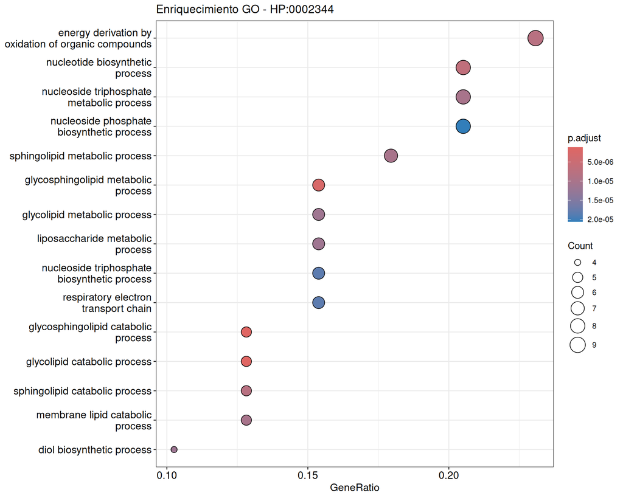

```r
if(nrow(as.data.frame(enrich_all)) > 0){
  # Dotplot
  dotplot(enrich_all, showCategory = 15,
          title = "Enriquecimiento GO - HP:0002344")
}
```

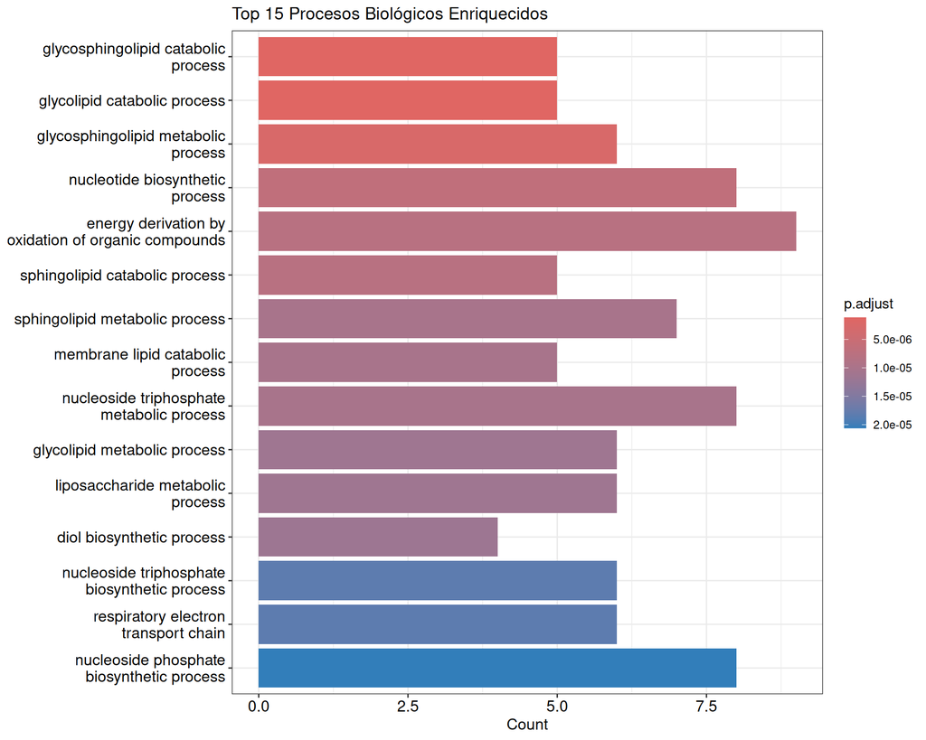

```r
if(nrow(as.data.frame(enrich_all)) > 0){
  # Barplot
  barplot(enrich_all, showCategory = 15,
          title = "Top 15 Procesos Biológicos Enriquecidos")
}
```

### 2.7.2 Enriquecimiento por comunidad

```r
# Análisis de enriquecimiento para cada comunidad
enrichment_by_community <- list()

for(i in seq_along(genes_by_community)){
  if(length(genes_by_community[[i]]) >= 5){  # Mínimo 5 genes
    tryCatch({
      enrichment_by_community[[i]] <- enrichGO(
        gene          = genes_by_community[[i]],
        OrgDb         = org.Hs.eg.db,
        keyType       = "SYMBOL",
        ont           = "BP",
        pAdjustMethod = "BH",
        pvalueCutoff  = 0.05,
        qvalueCutoff  = 0.2
      )
    }, error = function(e){
      # Silent error handling
    })
  }
}
```

```r
for(i in seq_along(enrichment_by_community)){
  if(!is.null(enrichment_by_community[[i]]) &&
     nrow(as.data.frame(enrichment_by_community[[i]])) > 0){

    cat(paste0("\n#### Comunidad ", i, "\n\n"))
    cat(paste0('<div class="alert alert-info">\n'))
    cat(paste0('<strong>Términos GO significativos:</strong> ',
               nrow(as.data.frame(enrichment_by_community[[i]])), '\n'))
    cat('</div>\n\n')

    print(
      head(as.data.frame(enrichment_by_community[[i]])[,
                               c("Description", "pvalue", "Count")], 5) %>%
        kbl(col.names = c("Descripción", "p-valor", "Genes")) %>%
        kable_styling(bootstrap_options = c("striped", "hover", "condensed"),
                      full_width = FALSE) %>%
        row_spec(0, bold = TRUE, color = "white", background = "#9b59b6")
    )
    cat("\n\n")
  }
}
```

[output not shown]

[output cut: 44 more lines]

[output not shown]

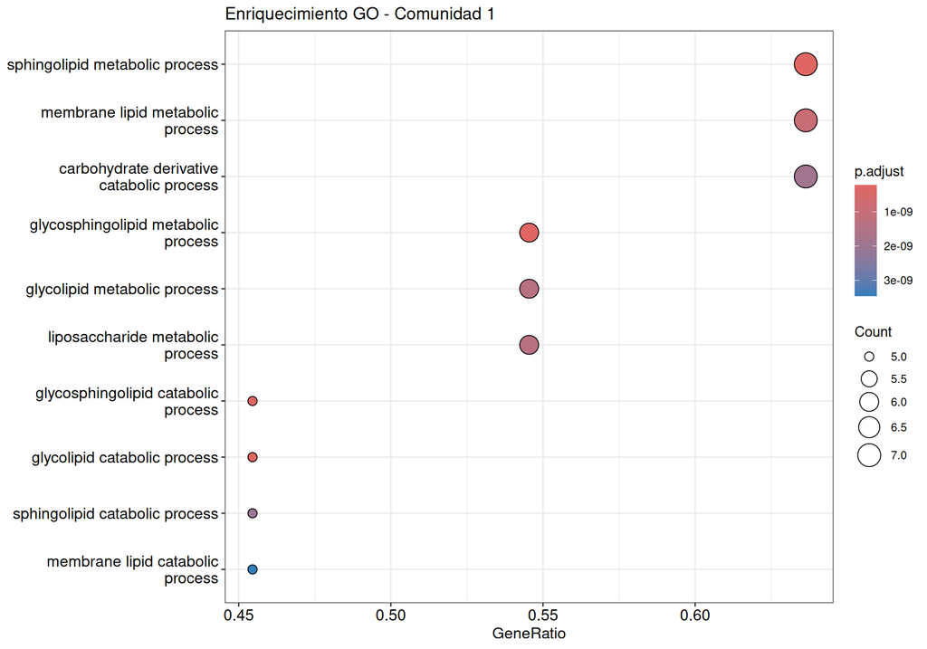

```r
# Visualizar enriquecimiento de la comunidad más grande
largest_community <- which.max(community_sizes)

if(!is.null(enrichment_by_community[[largest_community]]) &&
   nrow(as.data.frame(enrichment_by_community[[largest_community]])) > 0){

  dotplot(enrichment_by_community[[largest_community]],
          showCategory = 10,
          title = paste("Enriquecimiento GO - Comunidad", largest_community))
}
```

### 2.7.3 Enriquecimiento KEGG

```r
# Convertir símbolos a Entrez IDs
gene_entrez <- bitr(V(g)$name,
                    fromType = "SYMBOL",
                    toType = "ENTREZID",
                    OrgDb = org.Hs.eg.db)

# Análisis KEGG
enrich_kegg <- enrichKEGG(
  gene         = gene_entrez$ENTREZID,
  organism     = 'hsa',
  pvalueCutoff = 0.05,
  qvalueCutoff = 0.2
)
```

**✓ Análisis de enriquecimiento KEGG completado**  
**Vías KEGG significativas:** 25

```r
if(nrow(as.data.frame(enrich_kegg)) > 0){
  head(as.data.frame(enrich_kegg)[, c("ID", "Description", "pvalue", "Count")], 10) %>%
    kbl(caption = "Top 10 vías KEGG enriquecidas",
        col.names = c("ID KEGG", "Descripción", "p-valor", "Genes")) %>%
    kable_styling(bootstrap_options = c("striped", "hover", "condensed"),
                  full_width = FALSE) %>%
    row_spec(0, bold = TRUE, color = "white", background = "#e74c3c") %>%
    column_spec(3, color = "white", background = "#c0392b", bold = TRUE)
}
```

Top 10 vías KEGG enriquecidas

|  | ID KEGG | Descripción | p-valor | Genes |
| --- | --- | --- | --- | --- |
| hsa04142 | hsa04142 | Lysosome | 0.0000000 | 9 |
| hsa00600 | hsa00600 | Sphingolipid metabolism | 0.0000000 | 6 |
| hsa00531 | hsa00531 | Glycosaminoglycan degradation | 0.0000003 | 4 |
| hsa00511 | hsa00511 | Other glycan degradation | 0.0000249 | 3 |
| hsa00190 | hsa00190 | Oxidative phosphorylation | 0.0000755 | 5 |
| hsa00790 | hsa00790 | Folate biosynthesis | 0.0000976 | 3 |
| hsa00020 | hsa00020 | Citrate cycle (TCA cycle) | 0.0001205 | 3 |
| hsa04932 | hsa04932 | Non-alcoholic fatty liver disease | 0.0001391 | 5 |
| hsa05415 | hsa05415 | Diabetic cardiomyopathy | 0.0004800 | 5 |
| hsa05208 | hsa05208 | Chemical carcinogenesis - reactive oxygen species | 0.0007634 | 5 |

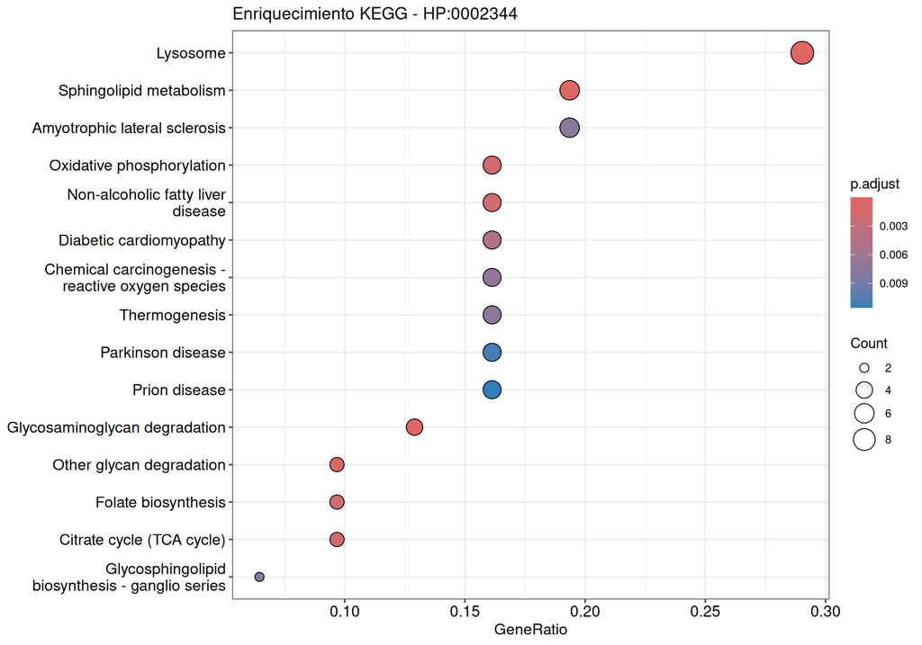

```r
if(nrow(as.data.frame(enrich_kegg)) > 0){
  dotplot(enrich_kegg, showCategory = 15,
          title = "Enriquecimiento KEGG - HP:0002344")
}
```

## 2.8 Exportación de Resultados

- Métricas de nodos (centralidad, grado, clustering)
- Resultados de enriquecimiento GO y KEGG
- Redes en formatos GraphML y GML

# 3 Resumen de Resultados

```r
# Crear dataframe de resumen
summary_df <- data.frame(
  Categoría = c(
    "Fenotipo HPO",
    "Genes totales identificados",
    "Genes en la red PPI",
    "Interacciones PPI",
    "Comunidades detectadas (Louvain)",
    "Modularidad de la red",
    "Grado medio",
    "Clustering global",
    "Términos GO enriquecidos",
    "Vías KEGG enriquecidas"
  ),
  Valor = c(
    paste(hpo_id, "- Progressive neurologic deterioration"),
    length(gene_list),
    vcount(g),
    ecount(g),
    n_communities_louvain,
    round(modularity_val, 3),
    round(mean(degree_vals), 2),
    round(global_clustering, 3),
    nrow(as.data.frame(enrich_all)),
    nrow(as.data.frame(enrich_kegg))
  )
)

summary_df %>%
  kbl(caption = "Resumen del análisis completo") %>%
  kable_styling(bootstrap_options = c("striped", "hover"),
                full_width = FALSE) %>%
  row_spec(0, bold = TRUE, color = "white", background = "#2c3e50") %>%
  column_spec(1, bold = TRUE, width = "18em") %>%
  column_spec(2, width = "15em")
```

Resumen del análisis completo

| Categoría | Valor |
| --- | --- |
| Fenotipo HPO | HP:0002344 - Progressive neurologic deterioration |
| Genes totales identificados | 73 |
| Genes en la red PPI | 39 |
| Interacciones PPI | 43 |
| Comunidades detectadas (Louvain) | 10 |
| Modularidad de la red | 0.757 |
| Grado medio | 2.21 |
| Clustering global | 0.606 |
| Términos GO enriquecidos | 173 |
| Vías KEGG enriquecidas | 25 |

```r
# Estado de genes de interés
genes_status <- data.frame(
  Gen = focus_genes,
  Estado = ifelse(focus_genes %in% V(g)$name, "✓ PRESENTE", "✗ AUSENTE"),
  Grado = ifelse(focus_genes %in% V(g)$name,
                 degree(g, focus_genes[focus_genes %in% V(g)$name]),
                 NA)
)

genes_status %>%
  kbl(caption = "Estado de genes de interés en la red") %>%
  kable_styling(bootstrap_options = c("striped", "hover"),
                full_width = FALSE) %>%
  row_spec(0, bold = TRUE, color = "white", background = "#8e44ad") %>%
  column_spec(2, bold = TRUE,
              color = ifelse(genes_status$Estado == "✓ PRESENTE", "#27ae60", "#e74c3c"))
```

Estado de genes de interés en la red

[output not shown]

# 4 Información del Entorno

**Análisis completado:** 2025-11-14

**Repositorio:** [GitHub - Análisis HP:0002344](https://github.com/anubis-ai-agency/HP0002344-analysis)